# Recall: State of stress surrounding an arbitrarily deviated well

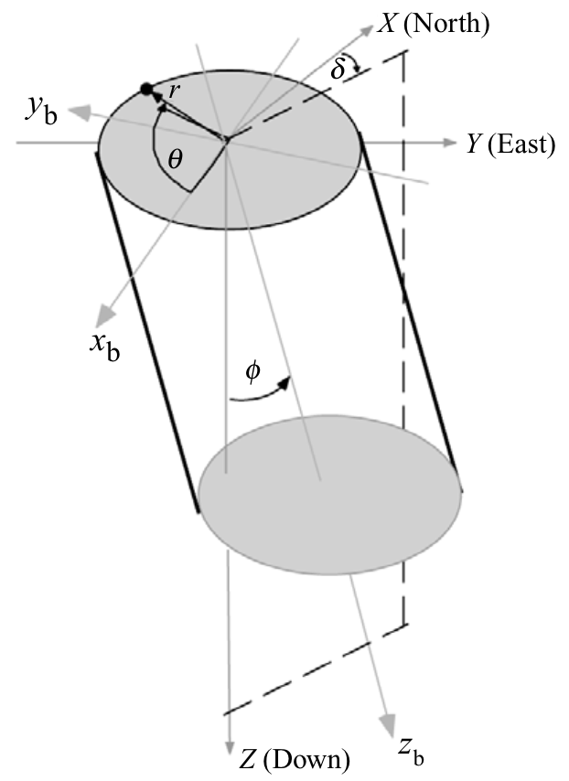

```python
import IPython.display
IPython.display.Image('images/deviate_well.png', width=300, embed=True)
```

© Cambridge University Press [Zoback, *Reservoir Geomechanics*](http://www.amazon.com/Reservoir-Geomechanics-Paperback-Author-Zoback/dp/B00EFZ88EQ/ref=sr_1_2?ie=UTF8&qid=1422942834&sr=8-2&keywords=zoback+geomechanics) (Fig. 8.1b, pp. 237)

# Stresses in the wellbore coordinate system

${}$

$$ \mathbf{R}_B = \begin{bmatrix} \cos\delta \cos\phi & \sin\delta \cos\phi & -\sin\phi \\ -\sin\delta & \cos\delta & 0 \\ \cos\delta\sin\phi & \sin\delta\sin\phi & \cos\phi \end{bmatrix} $$

$$ \mathbf{S}_B = \mathbf{R}_B \mathbf{S}_G \mathbf{R}_B^T $$

$$ \mathbf{S}_B = \mathbf{R}_B (\mathbf{R}_G^T \mathbf{S} \mathbf{R}_G) \mathbf{R}_B^T $$

# Stress at wellbore wall

${}$

\begin{align} \sigma_{zz} &= \sigma_{33} - 2 \nu (\sigma_{11} - \sigma_{22})\cos 2\theta - 4 \nu \sigma_{12} \sin 2 \theta \\ \sigma_{\theta\theta} &= \sigma_{11} + \sigma_{22} - 2(\sigma_{11} - \sigma_{22})\cos 2\theta - 4 \sigma_{12} \sin 2\theta - \Delta P \\ \tau_{\theta z} &= 2 (\sigma_{23} \cos \theta - \sigma_{13} \sin \theta) \\ \sigma_{rr} &= \Delta P \end{align}

# Principal effective stresses around the wellbore

${}$

[output not shown]

# Example: Reverse faulting

${}$

| $$\mathbf{S} = \begin{bmatrix} 30 & 0 & 0 \\ 0 & 25 & 0 \\ 0 & 0 & 20 \end{bmatrix}$$ | $$\quad\quad\quad$$ | \begin{align} \alpha &= 90^{\circ} & \mbox{Azimuth of } S_{Hmax} \\ \beta &= 0^{\circ} & S_1 = S_{Hmax} \\ \gamma &= 0^{\circ} & S_2 = S_{hmin} \end{align} |
| --- | --- | --- |

Find the minimum and maximum tangential stress for an open hole well that is oriented $20^\circ$ from North and deviated $20^{\circ}$ from vertical at a depth of $2$ km. Assume a hydrostatic pore pressure gradient, a Poisson ration of $0.2$, and a balanced drilling operation.

# Lower hemisphere projection

${}$

[figure not shown]

© Cambridge University Press [Zoback, *Reservoir Geomechanics*](http://www.amazon.com/Reservoir-Geomechanics-Paperback-Author-Zoback/dp/B00EFZ88EQ/ref=sr_1_2?ie=UTF8&qid=1422942834&sr=8-2&keywords=zoback+geomechanics) (Fig. 8.1a, pp. 237)

# Example

${}$

[figure not shown]

# Examples: Breakout initiation

${}$

| Normal | Strike-slip | Reverse |
| --- | --- | --- |

© Cambridge University Press [Zoback, *Reservoir Geomechanics*](http://www.amazon.com/Reservoir-Geomechanics-Paperback-Author-Zoback/dp/B00EFZ88EQ/ref=sr_1_2?ie=UTF8&qid=1422942834&sr=8-2&keywords=zoback+geomechanics) (Fig. 8.2a,b,c, pp. 240)

# Examples: Drilling induced tensile fracture

${}$

| Normal | Strike-slip | Reverse |
| --- | --- | --- |

© Cambridge University Press [Zoback, *Reservoir Geomechanics*](http://www.amazon.com/Reservoir-Geomechanics-Paperback-Author-Zoback/dp/B00EFZ88EQ/ref=sr_1_2?ie=UTF8&qid=1422942834&sr=8-2&keywords=zoback+geomechanics) (Fig. 8.3a,b,c, pp. 240)

[figure not shown]